# Modeling and prediction for movies

Rony Sulca

## Setup

### Load packages

```r
library(ggplot2)
library(dplyr)
library(statsr)
library(zoo)
library(gridExtra)
```

### Load data

```r
load("movies.Rdata")
```

## Part 1: Data

In this project, we examine a dataset of movies, which includes their attributions, ratings, and rewards. This dataset is obtained from Rotten Tomatoes and IMDB, two databases of information about movies, movie reviews, and opinions. It includes 651 randomly selected (without replacement) movies that premiered before 2016, along with multiple features about the movies and their reception.

Since these results are from past years, we can only make inferences from any analysis using this data, and there can be no casuality concluded from it. Also, since this dataset contains a random sample of all the movies released before 2016, and this sample is a very small portion of all the movies released (<<10%), then we can confidently consider it an satisfactory representation of the movies released before 2016 (and post 1970).

The variety of release years in our dataset allows us to investigate patterns that spread, or change, throught the decades. Because of this, we will be investigating if a few features of the movie can accurately predict its success, depending on the year/month it took place.

## Part 2: Research question

**Are a movie’s genre and runtime, as well as its date of release, useful predictors of how the movie is received by the audience and critics?**

This question spearheads our investigation of the impact, or lack thereof, of the genre and runtime of a movie on its reception. Since the taste in movies may vary throughout the years, we should include the dates in our investigation in order to take into account those changing tastes. This can help us account for timeframes where some genres are preferred to others, and timeframes where these preferences change drastically.

## Part 3: Exploratory data analysis

We begin our exploration of the data by selecting the relevant features.

##### Feature Selection

These relevant features are the movie genre, the runtime, theatrical year of release (thtr_rel_year), theatrical month of release (thtr_rel_month), the critics’ score, and the audiences’ score.

```r
movies_data = movies %>%
  select(c('genre', 'runtime', 'thtr_rel_year',
           'thtr_rel_month', 'critics_score', 'audience_score'))

head(movies_data)
```

```
## # A tibble: 6 x 6
##   genre       runtime thtr_rel_year thtr_rel_month critics_score audience~
##   <fctr>        <dbl>         <dbl>          <dbl>         <dbl>     <dbl>
## 1 Drama          80.0          2013           4.00          45.0      73.0
## 2 Drama         101            2001           3.00          96.0      81.0
## 3 Comedy         84.0          1996           8.00          91.0      91.0
## 4 Drama         139            1993          10.0           80.0      76.0
## 5 Horror         90.0          2004           9.00          33.0      27.0
## 6 Documentary    78.0          2009           1.00          91.0      86.0
```

We then proceed to look for missing values in our data.

```r
summary(movies_data)
```

```
##                 genre        runtime      thtr_rel_year  thtr_rel_month
##  Drama             :305   Min.   : 39.0   Min.   :1970   Min.   : 1.00
##  Comedy            : 87   1st Qu.: 92.0   1st Qu.:1990   1st Qu.: 4.00
##  Action & Adventure: 65   Median :103.0   Median :2000   Median : 7.00
##  Mystery & Suspense: 59   Mean   :105.8   Mean   :1998   Mean   : 6.74
##  Documentary       : 52   3rd Qu.:115.8   3rd Qu.:2007   3rd Qu.:10.00
##  Horror            : 23   Max.   :267.0   Max.   :2014   Max.   :12.00
##  (Other)           : 60   NA's   :1
##  critics_score    audience_score
##  Min.   :  1.00   Min.   :11.00
##  1st Qu.: 33.00   1st Qu.:46.00
##  Median : 61.00   Median :65.00
##  Mean   : 57.69   Mean   :62.36
##  3rd Qu.: 83.00   3rd Qu.:80.00
##  Max.   :100.00   Max.   :97.00
##
```

The Summary shows us that the runtime variable has a missing value. Since the missing value is only one in 651, we simply remove it.

```r
movies_data = movies_data %>%
  filter(!is.na(runtime))
```

##### Score Calculation

We then calculate the response variable. Since we are trying to predict the impact on the audience and critics score, we can combine both variables into one. Before doing so, we must analyze the differences in the variables in order to gauge how to properly combine them.

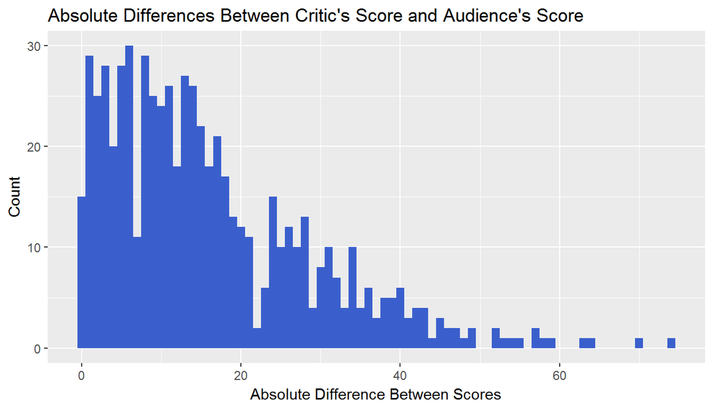

```r
score_differences = movies_data %>%
  mutate(score_diff = abs(critics_score - audience_score)) %>%
  select(score_diff)

ggplot(score_differences) +
  geom_histogram(aes(score_diff), fill = 'royalblue3', binwidth = 1) +
  ggtitle("Absolute Differences Between Critic's Score and Audience's Score") +
  xlab('Absolute Difference Between Scores') +
  ylab('Count') +
  guides(fill = FALSE)
```

```r
## SUMMARY STATISTICS
score_differences %>%
  summarise(Standard_Deviation = sd(score_diff), Mean = mean(score_diff))
```

```
## # A tibble: 1 x 2
##   Standard_Deviation  Mean
##                <dbl> <dbl>
## 1               13.0  16.1
```

As we can see in the plot, sometimes the critics’ score can vary greatly from the audiences’ score. Some of those differences can be very large, over 60 points! So it is difficult to properly gauge reception by using only one of these two. Not only that, the average of the differences is not even zero, therefore we cannot even consider these differences to be rare ocurrences (we can see this both from the summary mean and the height of the zero bar in the plot).

As a result, we opt to use the average of these two scores to come up with a measure that encapsulates the impact of both the audience score, and the critics’ score.

```r
movies_data = movies_data %>%
  ## creating new column
  mutate(score = (audience_score + critics_score) / 2) %>%
  ## Dropping original scores
  select(-c(critics_score, audience_score))

head(movies_data)
```

```
## # A tibble: 6 x 5
##   genre       runtime thtr_rel_year thtr_rel_month score
##   <fctr>        <dbl>         <dbl>          <dbl> <dbl>
## 1 Drama          80.0          2013           4.00  59.0
## 2 Drama         101            2001           3.00  88.5
## 3 Comedy         84.0          1996           8.00  91.0
## 4 Drama         139            1993          10.0   78.0
## 5 Horror         90.0          2004           9.00  30.0
## 6 Documentary    78.0          2009           1.00  88.5
```

This score can help us understand if a movie has been praised thorughout all facets of the audiences (critics and viewers), only part of them, or by none.

##### Genre

Now, when we study the impact of genre on a movie’s success, we can find some simple patterns by seeing their distribution of success.

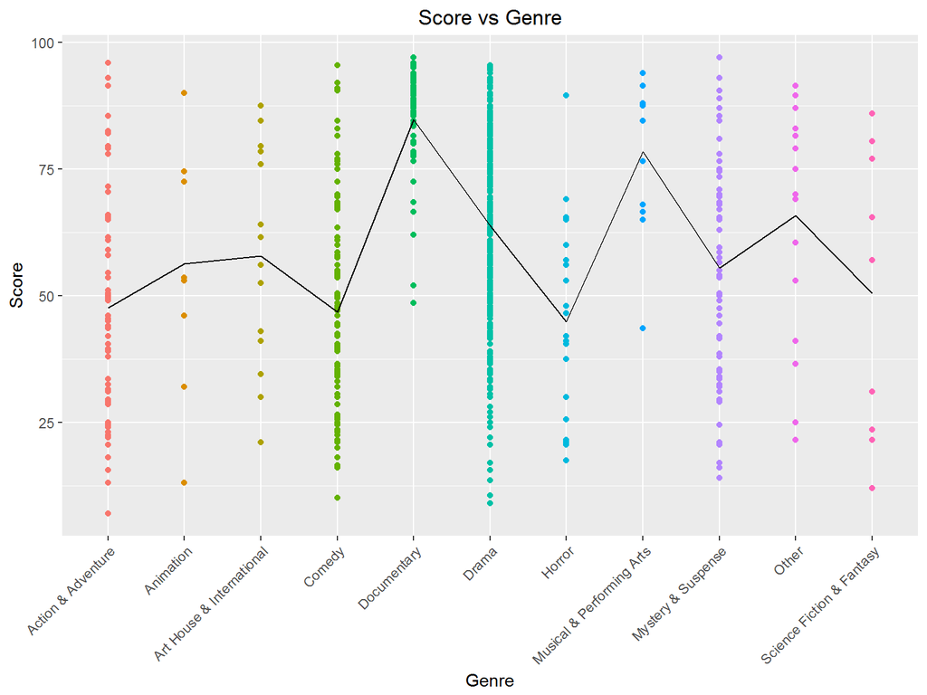

```r
ggplot(movies_data) +
  geom_point(aes(x = genre, y = score, colour = genre)) +
  stat_summary(aes(x = genre, y = score, group = 1),
               geom = 'line', colour = 'black', fun.y = mean, group = 1) +
  guides(colour = FALSE) +
  ggtitle('Score vs Genre') +
  xlab('Genre') +
  ylab('Score') +
  theme(plot.title = element_text(hjust = 0.5),
        axis.text.x = element_text(angle = 45, hjust = 1))
```

This plot shows us the performance of movies grouped by their genre. We see that some genres average higher than others (marked by the black line). This feature may help us predict the performance of a movie, but, as we can see in the plot, every genre has a lot of variability.

To help with the prediction, we go an extra dimension and add timeframes to our plot.

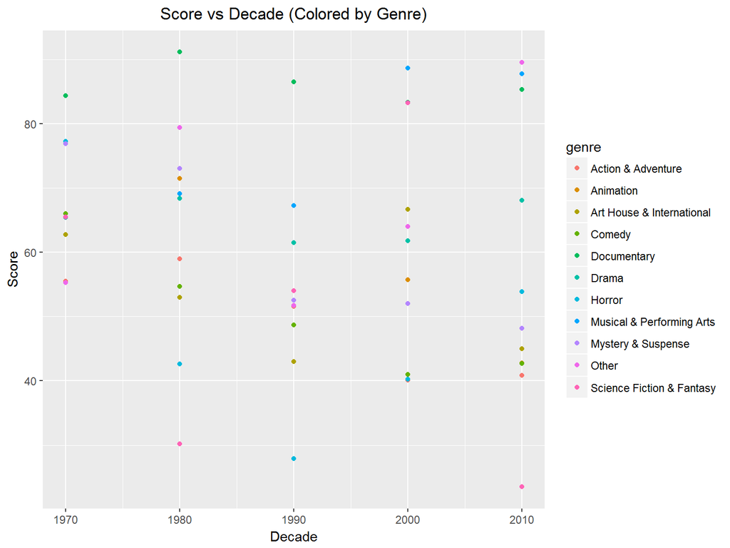

```r
movies_data %>%
  mutate(decade = thtr_rel_year - (thtr_rel_year %% 10)) %>%
  group_by(decade, genre) %>%
  summarise(score = mean(score)) %>%
  as.data.frame() %>%
  ggplot() +
  geom_point(aes(x = decade, y = score, colour = genre)) +
  ggtitle('Score vs Decade (Colored by Genre)') +
  xlab('Decade') +
  ylab('Score') +
  theme(plot.title = element_text(hjust = 0.5))
```

This variation among the decades makes the addition of dates to our model very important. Furthermore, this logic can also be applied to runtime, thus fortifying the usefulness of adding the dates.

Given these variables, we move onto the modeling phase.

## Part 4: Modeling

##### Variables

Now, that we have the relevant variables to answer our research question, we can begin building the model. First, we notice the variables we will be using. The research question clearly states we are looking for the impact the genre and runtime have on our score, so those, along with the dates, are the ones will be using. A date is broken into variables year and month since the time of the year (month) can have a different impact on a movie’s success than generational changes in taste (year).

There are different features in the original ‘movies’ dataset that we have avoided. These has been done for two reasons: 1) First, for the obvious reason that the research question does not involve them (This is why we have not used variables like studio and director). 2) Second, we omit them because they are not helpful for the predictive model we wish to build. For example, we first ignore the useless variables (like Url, etc.). Then, we note the categorical variables too many levels, like the director, actor, etc., which also offer little value in this analysis; so we omit them. Finally, there are a few variables that can provide very useful information to predict the performance of the movie, the ‘awards’ (of the movie) variables. Unfortunately, since this model wishes to predict the reception of upcoming movies, we cannot use variables that occur only after the movie has come out and its reception is already known.

##### Model Selection

From the multiple methods of model selection, we choose Forward Selection with ${R^2}_{adj}$ (Adjusted R Squared score). This choice comes from multiple reasons:

1. ${R^2}_{adj}$ is a little more accurate than using the p-value. This is specially helpful in this analysis because we are using very few variables.
2. Again, since we have a few number of variables, using backward propagation may result in eliminating no variables in the first step, and thus result in a very uninvolved process. For the sake of practice, we prefer the forward selection because it will force us to excute the algorithm until all variable combinations are explored.

We begin the model selection process with the variable ‘genre’.

```r
step1 = lm(data = movies_data, score ~ genre)
summary(step1)
```

```
##
## Call:
## lm(formula = score ~ genre, data = movies_data)
##
## Residuals:
##     Min      1Q  Median      3Q     Max
## -54.784 -14.766   1.392  15.216  48.787
##
## Coefficients:
##                                Estimate Std. Error t value Pr(>|t|)
## (Intercept)                      47.608      2.482  19.183  < 2e-16 ***
## genreAnimation                    8.726      7.116   1.226   0.2206
## genreArt House & International   10.214      5.895   1.733   0.0837 .
## genreComedy                      -0.895      3.280  -0.273   0.7851
## genreDocumentary                 37.108      3.743   9.915  < 2e-16 ***
## genreDrama                       16.176      2.733   5.918 5.32e-09 ***
## genreHorror                      -2.716      4.854  -0.560   0.5760
## genreMusical & Performing Arts   30.809      6.287   4.901 1.21e-06 ***
## genreMystery & Suspense           7.833      3.598   2.177   0.0298 *
## genreOther                       18.174      5.584   3.255   0.0012 **
## genreScience Fiction & Fantasy    2.837      7.116   0.399   0.6903
## ---
## Signif. codes:  0 '***' 0.001 '**' 0.01 '*' 0.05 '.' 0.1 ' ' 1
##
## Residual standard error: 20.01 on 639 degrees of freedom
## Multiple R-squared:  0.2219, Adjusted R-squared:  0.2097
## F-statistic: 18.22 on 10 and 639 DF,  p-value: < 2.2e-16
```

As expected from a categorical variable, the predictor variable is broken down into its many levels. For us to find whether this variable is valuable in this first step, we look at its p-value (Pr(>|t|)) [In the next steps we will begin using the ${R^2}_{adj}$]. We only need one of them to be impactful (have a small p-value) for us to keep them all since we cannot remove other levels of a categorical variable once we include one.

We note that many genre had a very tiny p-value, like Documentary for example. As a result we keep this field as a useful predictor.

```r
step2_a = lm(data = movies_data, score ~ genre + runtime)

step2_b = lm(data = movies_data, score ~ genre + thtr_rel_year)

step2_c = lm(data = movies_data, score ~ genre + thtr_rel_month)

data.frame(runtime = summary(step2_a)$adj.r.squared,
           theatrical_year = summary(step2_b)$adj.r.squared,
           theatrical_month = summary(step2_c)$adj.r.squared)
```

```
##     runtime theatrical_year theatrical_month
## 1 0.2327589        0.222944        0.2100556
```

As we can see, the runtime seems to provide a better predictive value, coupled with the genre, than the other variables do. As a result, we keep it in our calculations moving forward. Our new ${R^2}_{adj}$ is 0.23276, and we now proceed to step 3.

```r
step3_a = lm(data = movies_data, score ~ genre + runtime + thtr_rel_year)

step3_b = lm(data = movies_data, score ~ genre + runtime + thtr_rel_month)

data.frame(theatrical_year = summary(step3_a)$adj.r.squared,
           theatrical_month = summary(step3_b)$adj.r.squared)
```

```
##   theatrical_year theatrical_month
## 1       0.2431573        0.2315683
```

In this 3rd step, we analyze the last two variables. The year of theatrical release provides a higher ${R^2}_{adj}$ than the month of teathrical release and the initial ${R^2}_{adj}$. As a result, we keep this variable moving forward. Our new ${R^2}_{adj}$ is 0.24316.

```r
step4 = lm(data = movies_data, score ~ genre + runtime + thtr_rel_year + thtr_rel_month)

data.frame(initial = summary(step3_a)$adj.r.squared,
           theatrical_month = summary(step4)$adj.r.squared)
```

```
##     initial theatrical_month
## 1 0.2431573        0.2419995
```

Finally, the ${R^2}_{adj}$ we obtain by including the month of theatrical release is lower than the one we obtained at the end of the last step. This tells us to avoid this feature when formulating the model. Therefore, the model we obtaina the end of step 3 is the final model we will proceed with.

```r
final_model = step3_a
```

##### Diagnostics of the Model

For this model to predict accurately, the variables must satisfy an array of conditions.

1. Linear relationships between numerical explanatory variables and the response variable.

To verify this conditions for all variables, we use residual plots and expect to find a random catter of residuals around 0.

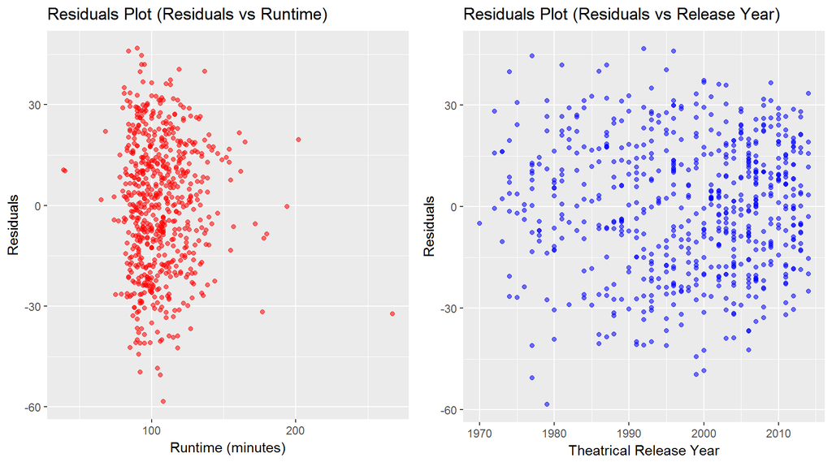

```r
plt1 = ggplot(movies_data) +
  geom_point(aes(y = final_model$residuals, x = runtime, alpha = 0.2), colour = 'red') +
  ggtitle('Residuals Plot (Residuals vs Runtime)') +
  xlab('Runtime (minutes)') +
  ylab('Residuals') +
  guides(color = FALSE, alpha = FALSE)

plt2 = ggplot(movies_data) +
  geom_point(aes(y = final_model$residuals, x = thtr_rel_year, alpha = 0.2), colour = 'blue') +
  ggtitle('Residuals Plot (Residuals vs Release Year)') +
  xlab('Theatrical Release Year') +
  ylab('Residuals') +
  guides(color = FALSE, alpha = FALSE)

grid.arrange(plt1, plt2, ncol = 2)
```

As these two plot show, the residuals for these two columns are evenly spread around 0, and show no changing trend over time. Therefore, we conclude the first condition is satisfied.

2. Nearly Normal Residuals with Mean 0

To check for this condition, we use a histogram and a normal probability plot. We expect to find, again, a random scatter around zero where some residuals are positive and some are negative.

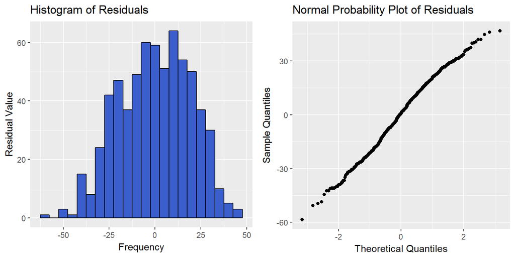

```r
plt1 = ggplot() +
  geom_histogram(aes(final_model$residuals), fill = 'royalblue3', color = 'black', binwidth = 5) +
  ggtitle("Histogram of Residuals") +
  xlab('Frequency') +
  ylab('Residual Value') +
  guides(fill = FALSE)

plt2 = qplot(sample = final_model$residuals) +
  ggtitle('Normal Probability Plot of Residuals') +
  xlab('Theoretical Quantiles') +
  ylab('Sample Quantiles')

grid.arrange(plt1, plt2, ncol = 2)
```

From the histogram, we can see that the residuals hapens randomly centered at 0, in a normal-like plot. The Probability plot also shows the residuals evenly spread around 0. Therefore, this condition is satisified.

3. Constant Variability of Residuals

In this condition, we need to verify that the residuals are equally variable for low and high values of the predicted response variable. To check this condition we use a plot of residuals vs the predicted values of y, and expect to see no increase/decrease (fan-shape) in the variability of residuals as the preicted value increases.

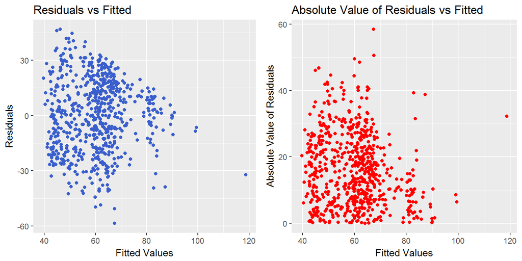

```r
plt1 = ggplot() +
  geom_point(aes(y = final_model$residuals, x = final_model$fitted.values),
             colour = 'royalblue3') +
  ggtitle("Residuals vs Fitted") +
  xlab('Fitted Values') +
  ylab('Residuals') +
  guides(colour = FALSE)

plt2 = ggplot() +
  geom_point(aes(y = abs(final_model$residuals), x = final_model$fitted.values),
             colour = 'red') +
  ggtitle("Absolute Value of Residuals vs Fitted") +
  xlab('Fitted Values') +
  ylab('Absolute Value of Residuals') +
  guides(colour = FALSE)
grid.arrange(plt1, plt2, ncol = 2)
```

Since we do not see any fan shape in either plot then we conclude that this condition is met. Note that the first plot shows a somewhat-inverse fan plot for the positive values, but this is not seen in the negative values, therefore, we assume this is just a random assortment of points.

4. Independent Residuals

For this final condition, we simply check if the order of data gathered influences somehow the trend in residuals. We expect to see no such trend if this condition is to be met.

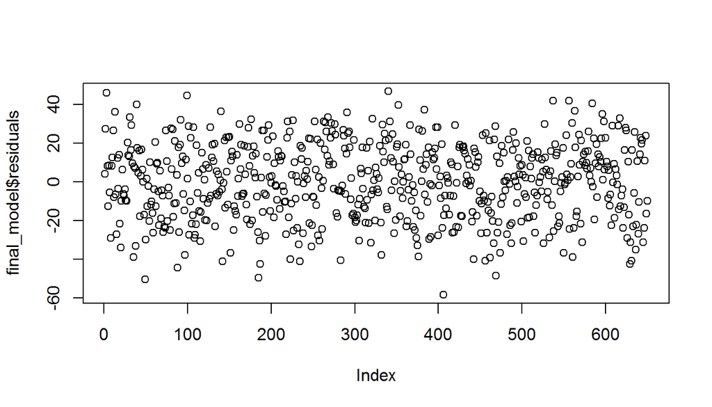

```r
plot(final_model$residuals)
```

As we can see in the sample, the order of data gathered does not at all influence the value of the residuals. So we finalize our Diagnostics phase concluding all four conditions have been met.

##### Interpretation of Coefficients

In our final step, we make sense of the coefficients our models has chosen for our features.

```r
summary(final_model)
```

```
##
## Call:
## lm(formula = score ~ genre + runtime + thtr_rel_year, data = movies_data)
##
## Residuals:
##     Min      1Q  Median      3Q     Max
## -58.422 -14.787   0.782  14.570  46.766
##
## Coefficients:
##                                 Estimate Std. Error t value Pr(>|t|)
## (Intercept)                    476.60983  143.69633   3.317 0.000962 ***
## genreAnimation                  13.13863    7.01044   1.874 0.061367 .
## genreArt House & International  10.91275    5.77092   1.891 0.059079 .
## genreComedy                      0.71912    3.22464   0.223 0.823600
## genreDocumentary                39.80884    3.69945  10.761  < 2e-16 ***
## genreDrama                      15.04250    2.69194   5.588 3.41e-08 ***
## genreHorror                     -0.97458    4.77838  -0.204 0.838453
## genreMusical & Performing Arts  29.35756    6.16795   4.760 2.40e-06 ***
## genreMystery & Suspense          7.06392    3.53394   1.999 0.046046 *
## genreOther                      15.44957    5.48951   2.814 0.005038 **
## genreScience Fiction & Fantasy   2.23584    6.97447   0.321 0.748638
## runtime                          0.17952    0.04227   4.247 2.49e-05 ***
## thtr_rel_year                   -0.22416    0.07173  -3.125 0.001859 **
## ---
## Signif. codes:  0 '***' 0.001 '**' 0.01 '*' 0.05 '.' 0.1 ' ' 1
##
## Residual standard error: 19.58 on 637 degrees of freedom
## Multiple R-squared:  0.2572, Adjusted R-squared:  0.2432
## F-statistic: 18.38 on 12 and 637 DF,  p-value: < 2.2e-16
```

As we can see the model, assigns a different coefficient to each category of the genre variable. This adds a new variable to the regression equation. If we were to order these coefficients, we would find that the Documentary genre predicts a much higher score (reception) than the other genres, with a whopping 39.8 higher predicted points than the default genre Action Adventure.

For the runtime variable, we can see that there is an increase of 0.18 score for each unit of runtime (minutes in our case).

Finally, for the year variable, we predict a smaller 0.22 score for each year forward. The earliest movie in our data is 1970.

Therefore the final predicting equation we obtain from this model can be written as

$$receptionscore = 476.61 + 0.1795(runtime) - 0.224(releaseyear) + \sum_{i}^{10} c_{i} * genre_{i}$$
where $c_{i}$ is the coefficient of the particular genre ‘i’, and $genre_{i}$ is either 1 or 0 depending on the genre of the movie.

## Part 5: Prediction

In this final step, we make a prediction of the reception a movie had using our model. We also provide a 95% confidence interval to this prediction. For this test we will be using a movie released on 2016, the science fiction film Arrival. We will acquire the necessary metrics of this movie from google (This data can be found doing a single google search with the word Arrival, and looking at the movie description given).

This confidence interval is defined as:

$$b_1 \pm t^*_{df} * SE_{b_{1}}$$

where $b_{1}$ is the intercept, $t^*_{df}$ is the t_statistic, and $SE_{b_{1}}$ is the standard error of the slope.

```r
# Creating data frame of new movie
arrival = data.frame(genre = factor('Science Fiction & Fantasy'), runtime = 116,
                     thtr_rel_year = 2016, score = (94+82)/2.0 )

# Confidence interval + real score
data.frame(predict(final_model, arrival, interval = "prediction", level = 0.95), real_score = arrival$score)
```

```
##        fit      lwr      upr real_score
## 1 47.75733 7.059077 88.45559         88
```

So, although the prediction itself is quite off, the confidence interval is accurate enough to contain the actual score of 88. That is, the confidence interval successfully encaptures the real reception score of the movie.

## Part 6: Conclusion

After finalizing our analysis on the relationship between a movie’s genre, runtime, and date with its reception by the audiences and critics, we have found that these fields can be helpful when predicting the reception movies will have. This reception, calculated as the average of the audience and the critics score, has a linear relationship with all of the numerical explanatory variables, as found in our model selection and diagnostics steps. As a result, we can successfully answer the research question by stating that: **The genre, runtime, and release year of a movie are indeed useful predictors for estimating the reception a movie will have.** This was further validated with our confidence interval containing the real score the movie Arrival received.

Unfortunately, our model does inded have considerable shortcomings. First, the summary of the model shows an ${R^2}_{adj}$ of 0.24 which is very low, meaning only about a quarter of the variability in the score can be explained by the model. This is verified by the middle range of our confidence interval being so far from the true score of Arrival, and the width of the interval almost being the entirity of the possible range 0-100. Therefore, if we wish to build a model that will very accurately predict the reception of the score, we need many more strongly predictive features in our dataset.